# ExtraaLearn Project

#### Recall and other evaluation metrics improves significantly in the Train data model on using Random forest Grid search optimized algorithm. The evaluation metrics including Recall deteriorates in the Test data compared to Train data but it is not significant decay. Recall and F1 score are still 85% in Test dataset

[figure not shown]

```python
imp_df = pd.DataFrame({
    "Feature Name": X_train.columns,
    "Importance": rfc.feature_importances_
})
fi = imp_df.sort_values(by="Importance", ascending=False)

fi2 = fi.head(6)
plt.figure(figsize=(10,8))
sns.barplot(data=fi2, x='Importance', y='Feature Name')
plt.title('Top 10 Feature Importance Each Attributes (Random Forest Grid search optimized model)', fontsize=10)
plt.xlabel ('Importance', fontsize=9)
plt.ylabel ('Feature Name', fontsize=9)
plt.show()
```

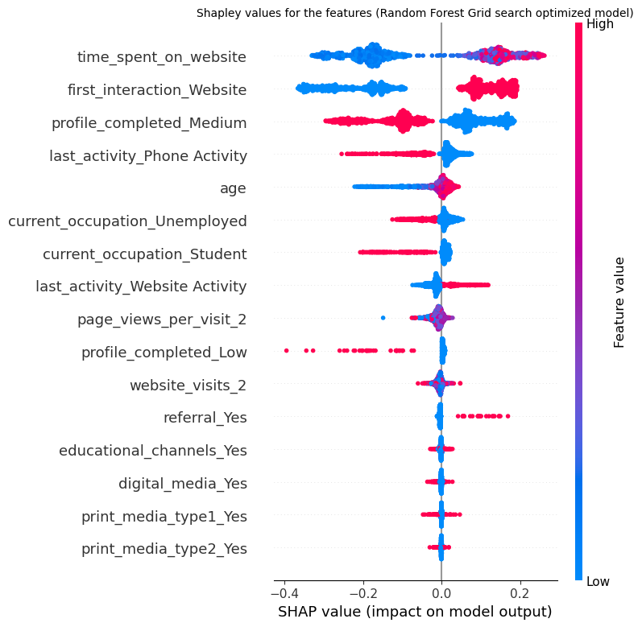

```python
import shap
plt.title('Shapley values for the features (Random Forest Grid search optimized model)', fontsize=10)
explainer = shap.TreeExplainer(rfc)
shap_values = explainer.shap_values(X_test)
shap.summary_plot(shap_values[1], X_test)
```

### Shapley value interpretation:

1. Variable like Time spent on Website, First Interaction using Website, Age, Last activity using Website, Referral: positive/higher values of these variables have a positive effect on the event variable (Conversion). Customers with positive/higher values of these variables have greater chance of converting to paid customers
2. On the other hand, variables such as Medium and Low profile completed, Last activity on Phone, Unemployed and Student occupation: Customers with lower values of these variables have greater chance of converting to paid customers. Hence these variables negatively impact the event of converting to paid customers

These insights are in-line with the exploratory trends in the data seen earlier

```python
pip install kds
```

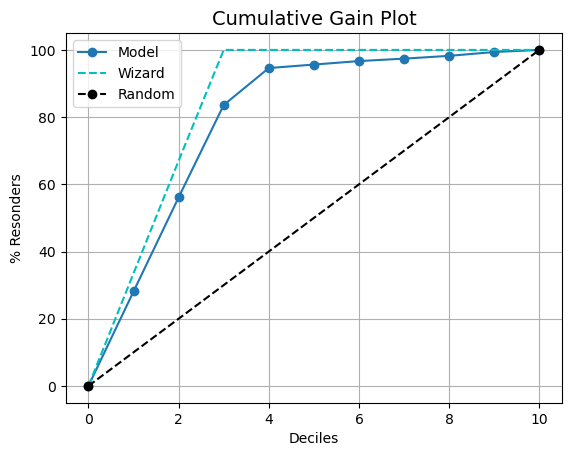

```python
#Gain chart on the Train data - Random Forest optimized model
import kds
kds.metrics.plot_cumulative_gain(y_train, y_pred_train_rfc)
```

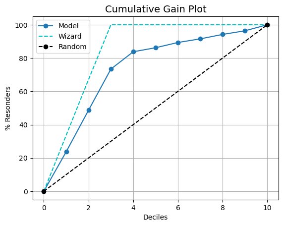

```python
#Gain chart on the Test data - Random Forest optimized model
import kds
kds.metrics.plot_cumulative_gain(y_test, y_pred_test_rfc)
```

## Actionable Insights and Recommendations

1) We can leverage the Random Forest model for effective lead targeting and prioritization. This model is performing quite well with a Recall of 85% in the Test data.  
2) Regarding the important drivers: Time spent on Website, First Interaction using Website, Age, Last activity using Website, Referral, Professionals are some of the significant drivers that for converting the leads to paid customers. The Ed Tech should focus on these aspects such as increasing the referral network, focus more on leads who are professionals currently, optimizing the website content etc.